# Wstęp do Uczenia Maszynowego 2020: projekt I, kamień milowy III - drzewa klasyfikacyjne

Jakub Kosterna

09/04/2020

# 1. Odczyt

W II kamieniu milowym dokonaliśmy porządnej inżynierii cech. Wczytajmy rezultat naszej pracy.

```r
library(dplyr)
X_train <- read.csv("x_train.csv")
X_test <- read.csv("x_test.csv")
y_train <- read.csv("y_train.csv")
y_test <- read.csv("y_test.csv")

X_test <- select(X_test, -X)
X_train <- select(X_train, -X)
y_test <- select(y_test, -X)
y_train <- select(y_train, -X)

colnames(y_train) <- "is_good_customer_type"
colnames(y_test) <- "is_good_customer_type"

knitr::kable(sample_n(X_train, 10))
```

| duration | credit_amount | installment_rate | present_residence | age | existing_credits | dependents | has_telephone | is_foreign_worker | has_problems_credit_history | purpose_domestic | purpose_retraining | purpose_radio_television | purpose_new_car | purpose_used_car | purpose_business | purpose_repairs | purpose_education | purpose_furniture_equipment | other_debtors_guarantor | other_debtors_co_applicant | other_installment_plans_bank | other_installment_plans_stores | housing_rent | housing_own | job_skilled_employee | job_unskilled_resident | job_highly_qualified_employee | savings | present_employment | … |
| --- | --- | --- | --- | --- | --- | --- | --- | --- | --- | --- | --- | --- | --- | --- | --- | --- | --- | --- | --- | --- | --- | --- | --- | --- | --- | --- | --- | --- | --- | --- |
| 15 | 1262 | 4 | 3 | 36 | 2 | 1 | 1 | 1 | 0 | 0 | 0 | 0 | 0 | 0 | 0 | 1 | 0 | 0 | 0 | 0 | 0 | 0 | 0 | 1 | 1 | 0 | 0 | 3 | 5 | … |
| 8 | 907 | 3 | 2 | 26 | 1 | 1 | 1 | 1 | 0 | 0 | 0 | 0 | 0 | 0 | 0 | 0 | 0 | 0 | 0 | 0 | 0 | 0 | 0 | 1 | 1 | 0 | 0 | 1 | 1 | … |
| 8 | 760 | 4 | 2 | 44 | 1 | 1 | 0 | 1 | 0 | 1 | 0 | 0 | 0 | 0 | 0 | 0 | 0 | 0 | 1 | 0 | 0 | 0 | 0 | 1 | 0 | 1 | 0 | 1 | 5 | … |
| 18 | 3229 | 2 | 4 | 38 | 1 | 1 | 1 | 1 | 1 | 0 | 0 | 0 | 0 | 1 | 0 | 0 | 0 | 0 | 0 | 0 | 0 | 0 | 0 | 1 | 0 | 0 | 1 | 0 | 0 | … |
| 48 | 15672 | 2 | 2 | 23 | 1 | 1 | 1 | 1 | 0 | 0 | 0 | 0 | 0 | 0 | 0 | 0 | 0 | 0 | 0 | 0 | 0 | 0 | 0 | 1 | 1 | 0 | 0 | 1 | 2 | … |
| 6 | 660 | 2 | 4 | 23 | 1 | 1 | 0 | 1 | 0 | 0 | 0 | 0 | 0 | 0 | 0 | 0 | 1 | 0 | 0 | 0 | 0 | 0 | 1 | 0 | 0 | 1 | 0 | 3 | 5 | … |
| 42 | 3394 | 4 | 4 | 65 | 2 | 1 | 0 | 1 | 1 | 0 | 0 | 0 | 0 | 0 | 0 | 0 | 1 | 0 | 0 | 1 | 0 | 0 | 0 | 1 | 0 | 0 | 0 | 1 | 0 | … |
| 6 | 590 | 3 | 3 | 26 | 1 | 1 | 0 | 0 | 0 | 1 | 0 | 0 | 0 | 0 | 0 | 0 | 0 | 0 | 0 | 0 | 0 | 0 | 0 | 1 | 0 | 1 | 0 | 1 | 1 | … |
| 12 | 1412 | 4 | 2 | 29 | 2 | 1 | 1 | 1 | 1 | 0 | 0 | 0 | 0 | 0 | 0 | 0 | 0 | 0 | 1 | 0 | 0 | 0 | 0 | 1 | 0 | 0 | 1 | 1 | 2 | … |
| 4 | 1544 | 2 | 1 | 42 | 3 | 2 | 0 | 1 | 1 | 1 | 0 | 0 | 0 | 0 | 0 | 0 | 0 | 0 | 0 | 0 | 0 | 0 | 0 | 1 | 0 | 1 | 0 | 1 | 5 | … |

```r
knitr::kable(sample_n(y_test, 10))
```

| is_good_customer_type |
| --- |
| 1 |
| 0 |
| 1 |
| 1 |
| 1 |
| 1 |
| 0 |
| 1 |
| 1 |
| 0 |

Wszystko jest w porządku! Możemy zacząć implementować nasze drzewo klasyfikacyjne.

# 2. Miary oceny klasyfikatora

W ocenie kolejnych modeli posłużę się czterema najbardziej klasycznymi miarami:

- *accuracy* - $\frac{TP+TN}{TP+FP+FN+TN}$
- *precision* - $\frac{TP}{TP+FP}$
- *recall* - $\frac{TP}{TP+FN}$
- *f1* - $2*\frac{Recall * Precision}{Recall + Precision}$

```r
confusion_matrix_values <- function(confusion_matrix){
TP <- confusion_matrix[2,2]
TN <- confusion_matrix[1,1]
FP <- confusion_matrix[1,2]
FN <- confusion_matrix[2,1]
return (c(TP, TN, FP, FN))
}

accuracy <- function(confusion_matrix){
conf_matrix <- confusion_matrix_values(confusion_matrix)
return((conf_matrix[1] + conf_matrix[2]) / (conf_matrix[1] + conf_matrix[2] + conf_matrix[3] + conf_matrix[4]))
}

precision <- function(confusion_matrix){
conf_matrix <- confusion_matrix_values(confusion_matrix)
return(conf_matrix[1]/ (conf_matrix[1] + conf_matrix[3]))
}

recall <- function(confusion_matrix){
conf_matrix <- confusion_matrix_values(confusion_matrix)
return(conf_matrix[1] / (conf_matrix[1] + conf_matrix[4]))
}

f1 <- function(confusion_matrix){
conf_matrix <- confusion_matrix_values(confusion_matrix)
rec <- recall(confusion_matrix)
prec <- precision(confusion_matrix)
return(2 * (rec * prec) / (rec + prec))
}
```

# 3. Najprostszy z najprostszych

Żeby trochę ugryźć temat, w pierwszej kolejności zajmę się najbardziej podstawowym wczytaniem i odtworzeniem modelu. Na kolejnych etapach będę próbował bawić się coraz to bardziej zaawansowanymi strukturami i wyborem hiperparametrów, ale idąc od rdzenia i będziemy mogli zaobserwować ewolucję skomplikowania kodu, ale także i porównań wyników, czy w praktyce będziemy mieli wyraźnie lepsze rozwiązanie.

Do konstrukcji classification trees użyję przydatnego pakietu **rpart**.

```r
library(rpart)
```

Wygenerujmy naszą pierwszą roślinkę.

```r
X <- cbind(X_train, y_train)

primitive_model <- rpart(is_good_customer_type ~ ., data = X, method = "class", control = rpart.control(cp = 0))
```

… i ją z wizualizujmy. Możemy to zrobić na trzy sposoby:

1. Po prostu wyczytując wartości z powstałej wygenerowanej zmiennej, która zawiera kluczowe przedziały
2. Użyć podstawowej wizualizacji, jaką oferuje **rpart.plot**.
3. Także skorzystać z pakietu *rpart.plot*, lecz z ułatwiającymi bonusami.

W pierwszej kolejności skorzystam ze wszystkich trzech opcji, dla kultury.

```r
library(rpart.plot)

primitive_model
```

```
## n= 800
##
## node), split, n, loss, yval, (yprob)
##       * denotes terminal node
##
##    1) root 800 236 1 (0.29500000 0.70500000)
##      2) checking_account_status>=0.5 491 201 1 (0.40936864 0.59063136)
##        4) duration>=22.5 204  97 0 (0.52450980 0.47549020)
##          8) purpose_used_car< 0.5 175  76 0 (0.56571429 0.43428571)
##           16) checking_account_status< 2.5 160  64 0 (0.60000000 0.40000000)
##             32) savings>=0.5 134  47 0 (0.64925373 0.35074627)
##               64) credit_amount>=4231 58  13 0 (0.77586207 0.22413793)
##                128) age< 29.5 26   1 0 (0.96153846 0.03846154) *
##                129) age>=29.5 32  12 0 (0.62500000 0.37500000)
##                  258) duration< 33 10   1 0 (0.90000000 0.10000000) *
##                  259) duration>=33 22  11 0 (0.50000000 0.50000000)
##                    518) duration>=47.5 12   3 0 (0.75000000 0.25000000) *
##                    519) duration< 47.5 10   2 1 (0.20000000 0.80000000) *
##               65) credit_amount< 4231 76  34 0 (0.55263158 0.44736842)
##                130) age< 54.5 69  28 0 (0.59420290 0.40579710)
##                  260) housing_rent>=0.5 19   3 0 (0.84210526 0.15789474) *
##                  261) housing_rent< 0.5 50  25 0 (0.50000000 0.50000000)
##                    522) credit_amount< 2211.5 16   4 0 (0.75000000 0.25000000) *
##                    523) credit_amount>=2211.5 34  13 1 (0.38235294 0.61764706)
##                     1046) age>=40 8   2 0 (0.75000000 0.25000000) *
##                     1047) age< 40 26   7 1 (0.26923077 0.73076923) *
##                131) age>=54.5 7   1 1 (0.14285714 0.85714286) *
##             33) savings< 0.5 26   9 1 (0.34615385 0.65384615)
##               66) checking_account_status< 1.5 11   3 0 (0.72727273 0.27272727) *
##               67) checking_account_status>=1.5 15   1 1 (0.06666667 0.93333333) *
##           17) checking_account_status>=2.5 15   3 1 (0.20000000 0.80000000) *
##          9) purpose_used_car>=0.5 29   8 1 (0.27586207 0.72413793) *
##        5) duration< 22.5 287  94 1 (0.32752613 0.67247387)
##         10) has_problems_credit_history< 0.5 194  77 1 (0.39690722 0.60309278)
##           20) other_debtors_guarantor< 0.5 176  77 1 (0.43750000 0.56250000)
##             40) credit_amount< 1296 66  28 0 (0.57575758 0.42424242)
##               80) property< 1.5 21   2 0 (0.90476190 0.09523810) *
##               81) property>=1.5 45  19 1 (0.42222222 0.57777778)
##                162) duration>=11 29  13 0 (0.55172414 0.44827586)
##                  324) purpose_new_car>=0.5 7   1 0 (0.85714286 0.14285714) *
```

[output cut: 11 more lines]

```
##                     1336) duration>=13.5 7   2 0 (0.71428571 0.28571429) *
##                     1337) duration< 13.5 16   6 1 (0.37500000 0.62500000) *
##                    669) credit_amount>=2492 16   3 1 (0.18750000 0.81250000) *
##                  335) age>=29.5 47   7 1 (0.14893617 0.85106383) *
##           21) other_debtors_guarantor>=0.5 18   0 1 (0.00000000 1.00000000) *
##         11) has_problems_credit_history>=0.5 93  17 1 (0.18279570 0.81720430) *
##      3) checking_account_status< 0.5 309  35 1 (0.11326861 0.88673139)
##        6) credit_amount>=3891 68  16 1 (0.23529412 0.76470588)
##         12) present_employment< 3.5 35  14 1 (0.40000000 0.60000000)
##           24) purpose_used_car< 0.5 24  10 0 (0.58333333 0.41666667)
##             48) age< 30 8   1 0 (0.87500000 0.12500000) *
##             49) age>=30 16   7 1 (0.43750000 0.56250000) *
##           25) purpose_used_car>=0.5 11   0 1 (0.00000000 1.00000000) *
##         13) present_employment>=3.5 33   2 1 (0.06060606 0.93939394) *
##        7) credit_amount< 3891 241  19 1 (0.07883817 0.92116183) *
```

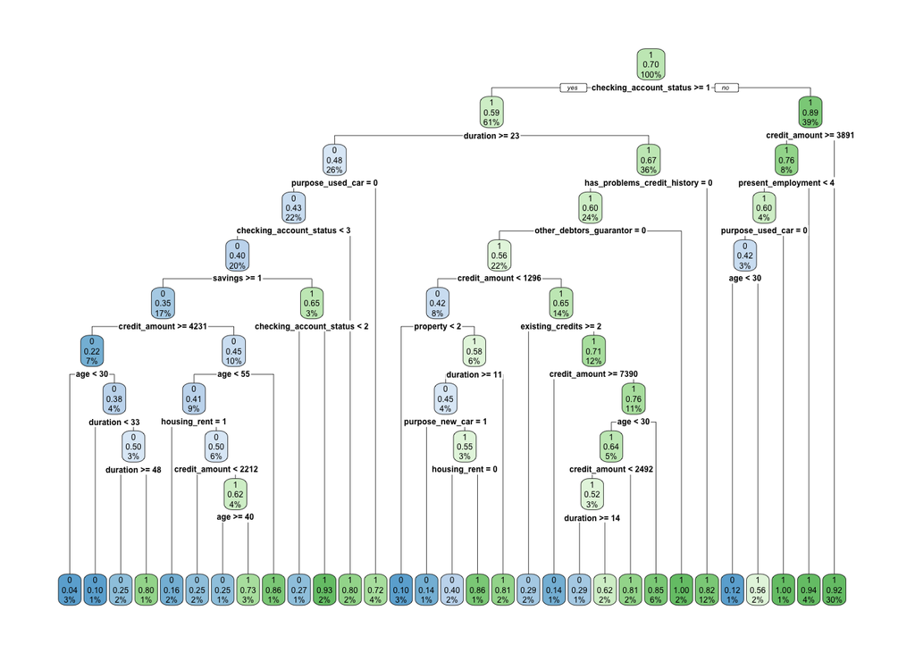

```r
rpart.plot(primitive_model)
```

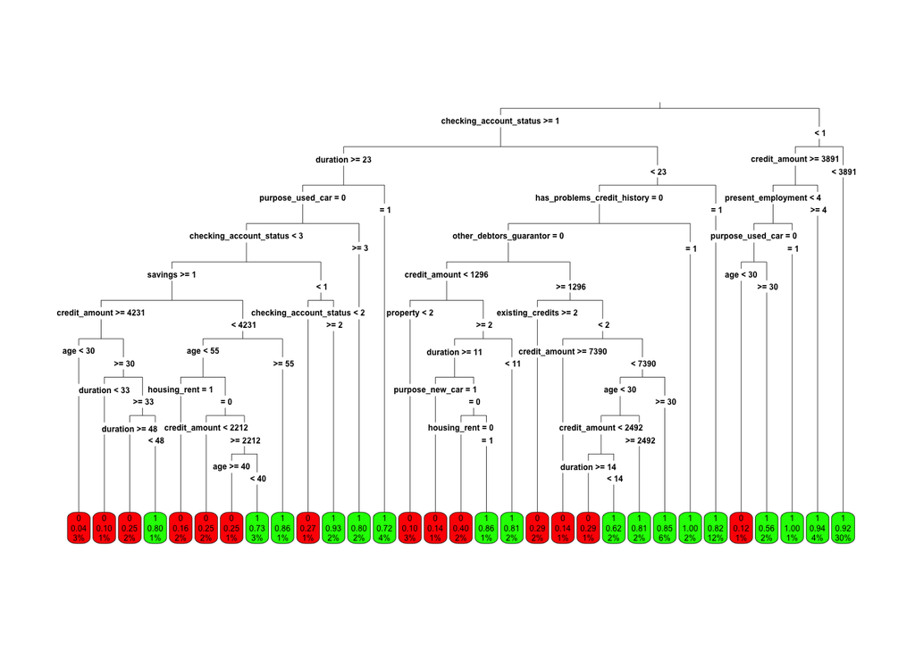

```r
rpart.plot(primitive_model, type = 3, box.palette = c("red", "green"), fallen.leaves = TRUE)
```

Woah! Jak widać, dużo cech poskutkowało także niewytłumaczalnym banalnie classification tree.

Sprawdźmy jeszcze, jak sobie ono radzi w akcji.

```r
y_pred <- predict(primitive_model, X_test, type = "class")
y_pred <- as.data.frame(y_pred)

confusion_matrix_primitive <- table(Truth = y_test$is_good_customer_type, Prediction = y_pred$y_pred)

knitr::kable(confusion_matrix_primitive)
```

|  | 0 | 1 |
| --- | --- | --- |
| 0 | 24 | 40 |
| 1 | 17 | 119 |

```r
accuracy_primitive <- accuracy(confusion_matrix_primitive)
precision_primitive <- precision(confusion_matrix_primitive)
recall_primitive <- recall(confusion_matrix_primitive)
f1_primitive <- f1(confusion_matrix_primitive)

classification_report_primitive <- data.frame(accuracy_primitive, precision_primitive,
recall_primitive, f1_primitive)
colnames(classification_report_primitive) <- c("accuracy", "precision",
"recall", "f1")
knitr::kable(classification_report_primitive)
```

| accuracy | precision | recall | f1 |
| --- | --- | --- | --- |
| 0.715 | 0.7484277 | 0.875 | 0.8067797 |

Jakby nie patrzeć całkiem satysfakcjonujące wyniki.

# 4. Drzewa z ustawionymi maksymalnymi poziomami wysokości

Może warto ograniczyć wysokość drzewa? Sprawdźmy to!

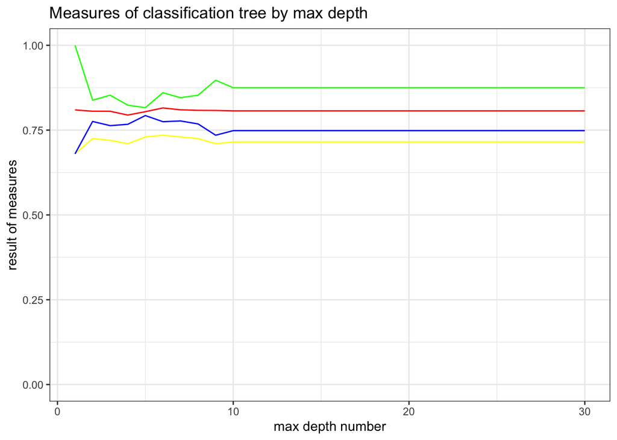

```r
indexes <- 1:30
with_max_depths_models <- list()
y_preds <- list()
acccuracy_scores <- list()
precision_scores <- list()
recall_scores <- list()
f1_scores <- list()

for (i in indexes){
with_max_depths_model <- rpart(is_good_customer_type ~ ., data = X, method = "class", control = rpart.control(cp = 0, maxdepth = i))
with_max_depths_models[[i]] <- with_max_depths_model
y_preds[[i]] <- predict(with_max_depths_model, X_test, type = "class")
confusion_matrix <- table(Truth = y_test$is_good_customer_type, Prediction = y_preds[[i]])

acccuracy_scores[[i]] <- accuracy(confusion_matrix)
precision_scores[[i]] <- precision(confusion_matrix)
recall_scores[[i]] <- recall(confusion_matrix)
f1_scores[[i]] <- f1(confusion_matrix)
}

acccuracy_scores <- unlist(acccuracy_scores)
precision_scores <- unlist(precision_scores)
recall_scores <- unlist(recall_scores)
f1_scores <- unlist(f1_scores)

measures <- data.frame(1:30, acccuracy_scores, precision_scores, recall_scores, f1_scores)

library(ggplot2)
ggplot(measures, aes(x = X1.30)) +
geom_line(aes(y = acccuracy_scores), color = "yellow") +
geom_line(aes(y = precision_scores), color = "blue") +
geom_line(aes(y = recall_scores), color = "green") +
geom_line(aes(y = f1_scores), color = "red") +
theme_bw() +
xlab("max depth number") +
ylab("result of measures") +
ylim(c(0, 1)) +
ggtitle("Measures of classification tree by max depth")
```

Co możemy stwierdzić po wykresie?

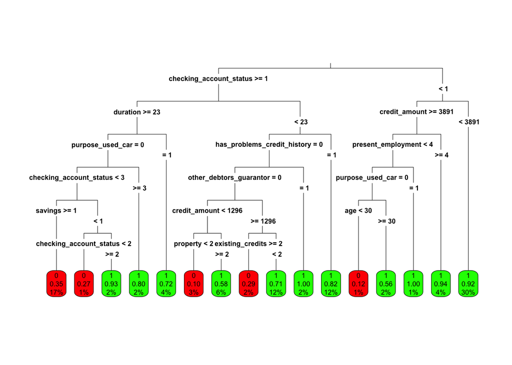

```r
maxd6_model <- rpart(is_good_customer_type ~ ., data = X, method = "class", control = rpart.control(cp = 0, maxdepth = 6))

rpart.plot(maxd6_model, type = 3, box.palette = c("red", "green"), fallen.leaves = TRUE)
```

```r
y_pred <- predict(maxd6_model, X_test, type = "class")
y_pred <- as.data.frame(y_pred)

confusion_matrix_maxd6 <- table(Truth = y_test$is_good_customer_type, Prediction = y_pred$y_pred)

knitr::kable(confusion_matrix_maxd6)
```

|  | 0 | 1 |
| --- | --- | --- |
| 0 | 30 | 34 |
| 1 | 19 | 117 |

```r
accuracy_maxd6 <- accuracy(confusion_matrix_maxd6)
precision_maxd6 <- precision(confusion_matrix_maxd6)
recall_maxd6 <- recall(confusion_matrix_maxd6)
f1_maxd6 <- f1(confusion_matrix_maxd6)

classification_report_maxd6 <- data.frame(accuracy_maxd6, precision_maxd6,
recall_maxd6, f1_maxd6)
colnames(classification_report_maxd6) <- c("accuracy", "precision",
"recall", "f1")
knitr::kable(classification_report_maxd6)
```

| accuracy | precision | recall | f1 |
| --- | --- | --- | --- |
| 0.735 | 0.7748344 | 0.8602941 | 0.815331 |

I już mamy miary fajniejsze!

# 5. Las losowy

```r
library(randomForest)

X$is_good_customer_type <- as.factor(X$is_good_customer_type)
random_forest <- randomForest(is_good_customer_type ~ ., data = X, proximity=T)

y_pred_forest <- predict(random_forest, X_test, method = "class")

confusion_matrix_forest <- table(Truth = y_test$is_good_customer_type, Prediction = y_pred_forest)

knitr::kable(confusion_matrix_forest)
```

|  | 0 | 1 |
| --- | --- | --- |
| 0 | 19 | 45 |
| 1 | 10 | 126 |

```r
accuracy_forest <- accuracy(confusion_matrix_forest)
precision_forest <- precision(confusion_matrix_forest)
recall_forest <- recall(confusion_matrix_forest)
f1_forest <- f1(confusion_matrix_forest)

classification_report_forest <- data.frame(accuracy_forest, precision_forest,
recall_forest, f1_forest)
colnames(classification_report_forest) <- c("accuracy", "precision",
"recall", "f1")
knitr::kable(classification_report_forest)
```

| accuracy | precision | recall | f1 |
| --- | --- | --- | --- |
| 0.725 | 0.7368421 | 0.9264706 | 0.8208469 |

# 6. Podsumowanie i najlepszy model

Porównajmy nasze miary.

```r
comparison_frame <- data.frame(rbind(classification_report_primitive, classification_report_maxd6, classification_report_forest))
comparison_frame <- cbind(model = c("primitive", "max depth: 6", "random forest"), comparison_frame)
comparison_frame
```

```
##           model accuracy precision    recall        f1
## 1     primitive    0.715 0.7484277 0.8750000 0.8067797
## 2  max depth: 6    0.735 0.7748344 0.8602941 0.8153310
## 3 random forest    0.725 0.7368421 0.9264706 0.8208469
```

Sprawa wyboru najlepszego modelu nie jest taka prosta. Biorąc pod uwagę **recall**, zdecydowanie najlepiej wypada *random forest* i także dla **f1** jest całkiem całkiem (choć tam bardzo małe różnice). Model ten radzi sobie jednak najgorzej w przypadku **precision**, gdzie dominuje ten, gdzie głębokość drzewa ograniczamy do 6. Ten sam model radzi sobie też najlepiej w przypadku **accuracy**, choć nie odstaje od swoich kolegów.

Na pewno **najgorzej wypadł model prymitywny**. Biorąc pod uwagę logikę biznesową i problem, uważam jednak **max depth = 6** za najlepszy - *precision* jest o tyle istotne, że nie chcemy dać zdolności kredytowej klientowi, który może zawalić i sprawić problemy. Niedanie pożyczki osobie, która prawdopodobnie nie zrobiłaby nic złego to potencjalnie mniejsza szkoda dla firmy.

Przyjrzyjmy się jeszcze raz naszemu najlepszemu drzewku.

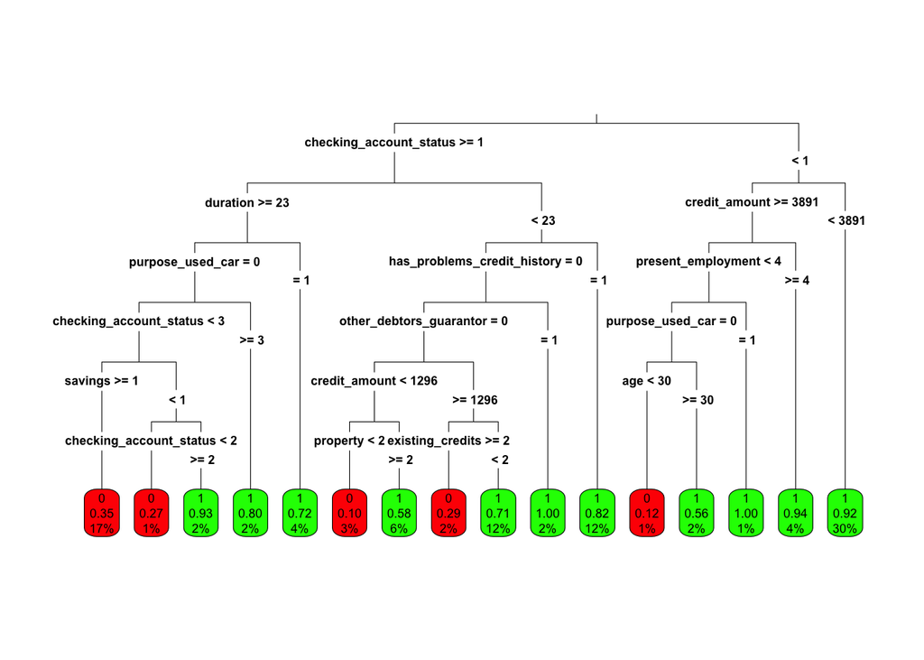

```r
rpart.plot(maxd6_model, type = 3, box.palette = c("red", "green"), fallen.leaves = TRUE)
```

Dodatkowym walorem modelu jest fakt, że jest dość prosty i łatwo wytłumaczalny. Prosto możemy przekazać, kto nie dostanie pożyczki.